# Hierarchical Clustering Analysis for Water Sheds in Santa Barbara County

- Show All Code
- Hide All Code
- View Source

Author

Travis Rennacker

# Overview

**Citation**: Santa Barbara Coastal LTER and J. Melack. 2019. SBC LTER: Land: Stream chemistry in the Santa Barbara Coastal drainage area, ongoing since 2000 ver 16. Environmental Data Initiative. https://doi.org/10.6073/pasta/67a558a24ceed9a0a5bf5e46ab841174.

This analysis will use Hierarchical Clustering to create associations from Water Chemistry

The data used in this analysis was collected by Santa Barbara Coastal LTER and catalogs water chemistry for major watersheds in the Santa Barbara area at key locations. Site codes were translated to water way names for clearer understanding of locations and associations. The data used for this analysis was taken from 2000-2018. We will use NH4, NO3, PO4, Total Dissolved Nutrients (TDN), Total Dissolved Particulate (TDP), Specific Conductivity (spec_cond) to perform our analysis. Euclidean Distances will be used to cluster results based on Complete Linkage and Single Linkage.

# Psuedo Code

1. Import Data
- Clean data set and perform name adjustments
- EDA of raw data
2. Drop Variables with low impact for better analysis
3. Perform Hierarchical Clustering
- Scale the data
- Calculate Euclidean distances from mean values of each variable
- Use Complete Linkage (smallest maximum distance) to form clusters
- Use Single Linkage (smallest distance) to form clusters

```r
library(tidyverse)
library(patchwork)
library(here)

# Packages for cluster analysis:
library(NbClust)
library(cluster)
library(factoextra)
library(dendextend)
library(ggdendro)
```

### Import .csv file and EDA

#### Import .csv

```r
water_chem_raw <- read_csv(here("data", "sbc_lter_registered_stream_chemistry.csv"))

water_chem_nine_nine <- water_chem_raw |> janitor::clean_names()
```

Clean up data frame and adjust names

```r
#get an idea of how many values.... wow a lot
nine_nine_nine <- sum(water_chem_nine_nine == -999)

nine_nine_nine

water_chem <- water_chem_nine_nine |> summary(-999)

#na.rm = TRUE

water_chem

water_chem_clean <- water_chem_nine_nine |>
  mutate(across(everything(), ~ replace(., . == -999, NA))) |>
  select(-tpc_u_m, -tpn_u_m,  -tpp_u_m, -tss_mgper_liter) |>
  rename(
    nh4 = nh4_u_m,
    no3 = no3_u_m,
    po4 = po4_u_m,
    tdn = tdn_u_m,
    tdp = tdp_u_m,
    spec_cond = spec_cond_u_spercm
  ) |>
  janitor::clean_names()

 sum(water_chem_nine_nine$spec_cond_u_spercm == -999)

 ggplot(water_chem_nine_nine, aes(x = spec_cond_u_spercm)) +
 geom_boxplot()
```

```r
 unique(water_chem_clean$site_code)
```

### Omitted Columns Explanation

These four metrics were chosen to be omitted from the analysis:

- Total Particulate Carbon: **tpc_u_m**
- Total Particulate Nitrogen: **tpn_u_m**
- Total particulate phosphorus: **tpp_u_m**
- Total Suspended Solids: **tss_mgper_liter**

All four of these metrics have a median value of -999. At least half of the values would be converted to NA and because of the necessity to occlude NA values for scaling and euclidean distance calculation the above four columns were omitted from analysis.

### Further EDA

```r
water_chem_long <- water_chem_clean %>%
  select(-timestamp_local) |>
  pivot_longer(cols = -site_code, names_to = 'variables', values_to = 'value') |> drop_na()

ggplot(water_chem_long, aes(x = value)) +
  geom_histogram() +
  facet_grid(site_code ~ variables, scales = 'free')
```

```r
#look at specific nutrients and site
ggplot(water_chem_clean) +
  geom_point(aes(x = nh4, y = no3, color = site_code),
             size = 3, alpha = 0.7)
```

```r
# visualize total dissolved nutrients and solids
ggplot(water_chem_clean) +
  geom_point(aes(x = tdn, y = tdp, color = site_code),
             size = 3, alpha = 0.7)
```

```r
#observe if time has anything to do with anything

ggplot(water_chem_clean) +
  geom_point(aes(x = timestamp_local, y = tdp, color = site_code),
             size = 3, alpha = 0.7)
```

# Hierarchical Clustering

#### Calculate mean values of all variables by site code and adjust site codes to common names

Converted site codes to water way names:

“RG01”: Refugio Creek

“AB00”: Arroyo Burro

“MC06”: Mission Creek at Rocky Nook

“MC00”:Mission Creek at Montecito St

“HO00”:Arroyo Hondo Creek

“RS02”:Rattlesnake Creek

“GV01”:Gaviota Creek

“AT07”:Atascadero Creek

“DV01”:Devereaux Slough

“BC02”:Bell Canyon Creek

“ON02”:San Onofre Creek

“TO02”:Tecolote Creek

“SP02”:San Pedro Creek

```r
# Drop rows where any of the measurements are missing and create mean values for each site

water_chem_mean <- water_chem_clean %>%
  select(-timestamp_local) |>             # Remove 'timestamp_local' column
  group_by(site_code) %>%              # Group data by 'site_code'
  summarise(
    nh4 = mean(nh4, na.rm = TRUE),         #Find mean values for each variable by site
    no3 = mean(no3, na.rm = TRUE),
    po4 = mean(po4, na.rm = TRUE),
    tdn = mean(tdn, na.rm = TRUE),
    tdp = mean(tdp, na.rm = TRUE),
    spec_cond = mean(spec_cond, na.rm = TRUE)) |>
  ungroup() |>
  mutate(                                    # Translate site_codes to creek names for recognition
    site_code = case_when(
      site_code == "RG01" ~ "Refugio_Creek",
      site_code == "AB00" ~ "Arroyo Burro",
      site_code == "MC06" ~ "Mission Creek at Rocky Nook",
      site_code == "MC00" ~ "Mission Creek at Montecito St",
      site_code == "HO00" ~ "Arroyo Hondo Creek",
      site_code == "RS02" ~ "Rattlesnake Creek",
      site_code == "GV01" ~ "Gaviota Creek",
      site_code == "AT07" ~ "Atascadero Creek",
      site_code == "DV01" ~ "Devereaux Slough",
      site_code == "BC02" ~ "Bell Canyon Creek",
      site_code == "ON02" ~ "San Onofre Creek",
      site_code == "TO02" ~ "Tecolote Creek",
      site_code == "SP02" ~ "San Pedro Creek",
    )
  )


# Little more EDA of mean values for variables by Site
ggplot(water_chem_mean) +
  geom_point(aes(x = tdn, y = tdp, color = site_code),
             size = 3, alpha = 0.7)
```

```r
ggplot(water_chem_mean) +
  geom_point(aes(x = nh4, y = no3, color = site_code),
             size = 3, alpha = 0.7)
```

#### Scaling

```r
# Only keep the columns for the measurements, then Scale the numeric variables
water_scale <- water_chem_mean %>%
  select(-site_code) %>%
  scale()

# add the site names in the row position

rownames(water_scale) <- water_chem_mean$site_code
```

#### Calculate Euclidean distances

```r
# Compute dissimilarity values (Euclidean distances):

euc_distance <- dist(water_scale, method = "euclidean")
```

#### Complete Linkage Plot

```r
# Hierarchical clustering (complete linkage)
water_complete <- hclust(euc_distance, method = "complete" )

# Plot it (base plot):
p_complete <- ggdendrogram(water_complete, rotate = TRUE) +
  theme_minimal() +
  labs(x = NULL, title = "Complete Linkage", y = NULL) +
    theme(
    axis.text.x = element_text(hjust = 1, size = 12, face = "bold"),
    axis.text.y = element_text(size = 12, face = "bold"),
    axis.title = element_text(size = 14, face = "bold"),
    plot.title = element_text(size = 16, face = "bold", hjust = 0.5),
    panel.grid.major = element_blank(),
    panel.grid.minor = element_blank(),
    plot.background = element_rect(fill = "cornsilk", color = "cornsilk")  # Background to cornsilk for clarity
  )
```

#### Single Linkage Plot

```r
# Hierarchical clustering (single linkage)
water_single <- hclust(euc_distance, method = "single" )

# Plot single

p_single <- ggdendrogram(water_single, rotate = TRUE) +
  theme_minimal() +
  labs(x = NULL, title = "Single Linkage", y = NULL) +
  theme(
    axis.text.x = element_text(hjust = 1, size = 12, face = "bold"),
    axis.text.y = element_text(size = 12, face = "bold"),
    axis.title = element_text(size = 14, face = "bold"),
    plot.title = element_text(size = 16, face = "bold", hjust = 0.5),
    panel.grid.major = element_blank(),
    panel.grid.minor = element_blank(),
    plot.background = element_rect(fill = "lightblue", color = "lightblue")  # Background to lightblue for clarity
  )
```

# Dendogram

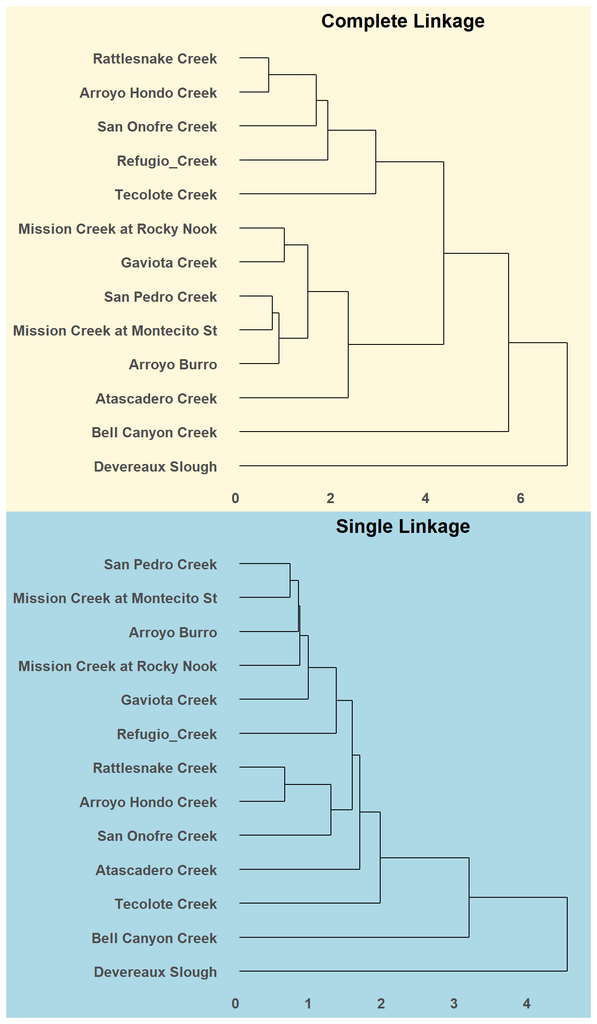

**Figure 1**, Complete Linkage Dendogram and Single Linkage Dendogram. The data for this analysis was taken from Santa Barbara watersheds from 2000-2018 and monitored for water qauality thorugh 6 metrics inlcuding: NH4, NO3, PO4, Total Dissolved Nutrients, Total Dissolved Particulate, Specific Conductivity. Euclidean Distance of means was used to create the clustering following complete and single linkage.

```r
# Compare the two dendrograms side by side
p_complete + p_single + plot_layout(ncol = 1)
```

# Summary

- These associations carry weight, due to the 18 years of the recorded data.
- Conceptually the transverse mountain range that defines Santa Barbara water sheds should also define the relationships, and it does, up to a point.
- Many of the grouping appear to follow geographical boundaries. Acceptions included in the Complete Linkage are Rattle Snake Creek (Monticeto) and Telecote Creek (Goleta). Both are linked with waterways further west in the Gaviota region. This points to some underlying similarities that could be explored with further analysis.
- Both Devereaux Slough and Bell Canyon show the least association with the rest of the groupings. Conceptually this makes sense because they are both smaller water sheds in West Goleta. Both carry different anthropogenic footprints. Devereaux Slough is adjacent to the Santa Barbara International Airport and the Community of Isla Vista (one of the most densely populated areas in California) and had the highest mean (by a large ) for Total Dissolved Solids. Bell Canyon is located in an agricultural area and had the highest mean (by a large margin) for Total Dissolved Nutrients.

These four metrics were chosen to be omitted from the analysis:

```
   - Total Particulate Carbon: **tpc_u_m**

   - Total Particulate Nitrogen: **tpn_u_m**

   - Total particulate phosphorus: **tpp_u_m**

   - Total Suspended Solids: **tss_mgper_liter**
```

All four of these metrics have a median value of -999. At least half of the values would be converted to NA and because of the necessity to occlude NA values for scaling and euclidean distance calculation the above four columns were omitted from analysis. Further analysis could be heightened through the inclusion of these variables.